# Estudios de Informática, Multimedia y Telecomunicaciones

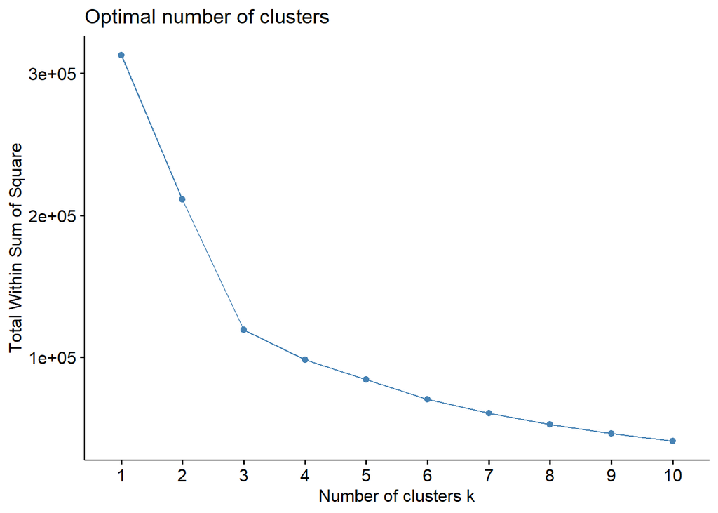

```r
#------------------------------------------------------------------------------
# check1: Hierarchical Clustering & elbow
fviz_nbclust(abs_df_clustering_check1, FUNcluster = hcut, method = "wss")
```

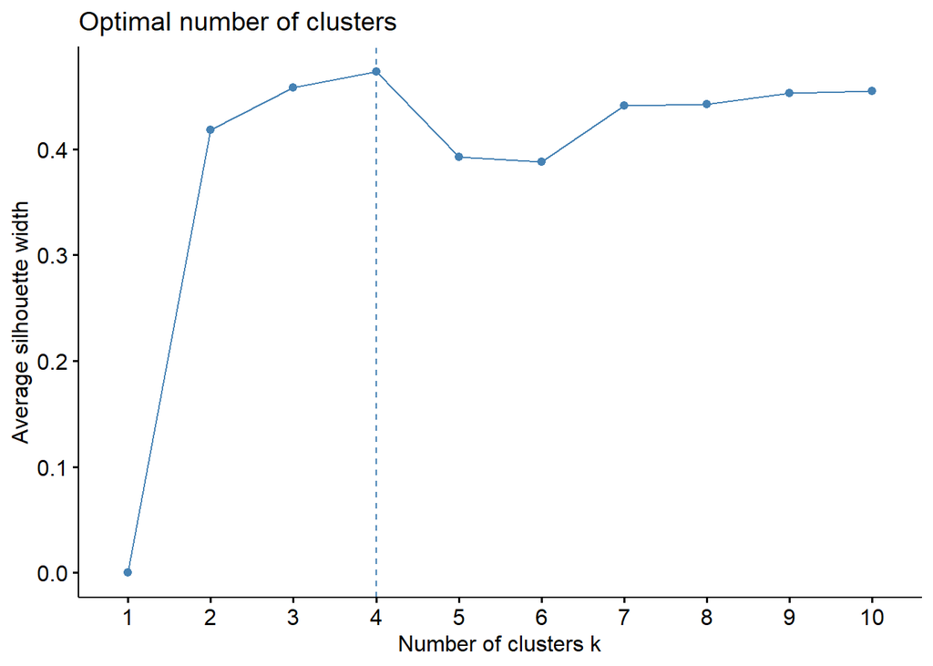

```r
# check2: Hierarchical Clustering & silhouette
fviz_nbclust(abs_df_clustering_check1, FUNcluster = hcut, method = "silhouette")
```

```r
#------------------------------------------------------------------------------

# check3: kmeansruns & CAlinsky-Harabasz/silhouette
fit_ch  <- kmeansruns(abs_df_clustering_check1, krange = 1:15, criterion = "ch")
fit_asw <- kmeansruns(abs_df_clustering_check1, krange = 1:15, criterion = "asw")

fit_ch$bestk
```

```
## [1] 3
```

```r
fit_asw$bestk
```

```
## [1] 4
```

```r
#------------------------------------------------------------------------------
```

Vemos que en general podemos llegar a tener entre 2 y 4 clusters.

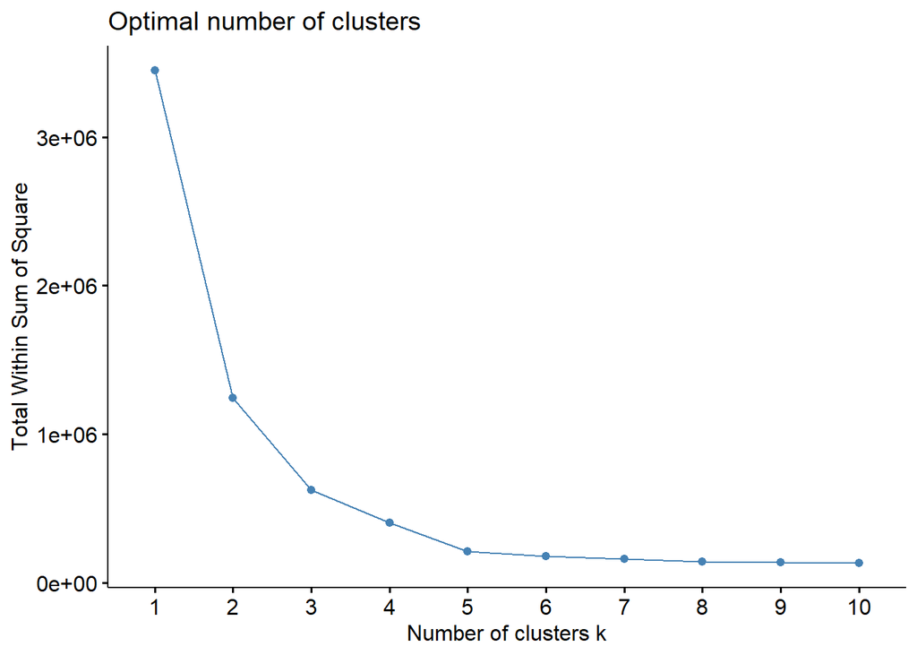

```r
set.seed(123)

#primeras 4 Variables de la componente principal PC1, orden creciente
abs_df_clustering_check2 = select(abs_df_reducido, Absenteeism.time.in.hours, Education, Pet, Transportation.expense, Social.smoker)


# check1: pam & elbow
fviz_nbclust(abs_df_clustering_check2, FUNcluster = pam, method = "wss")
```

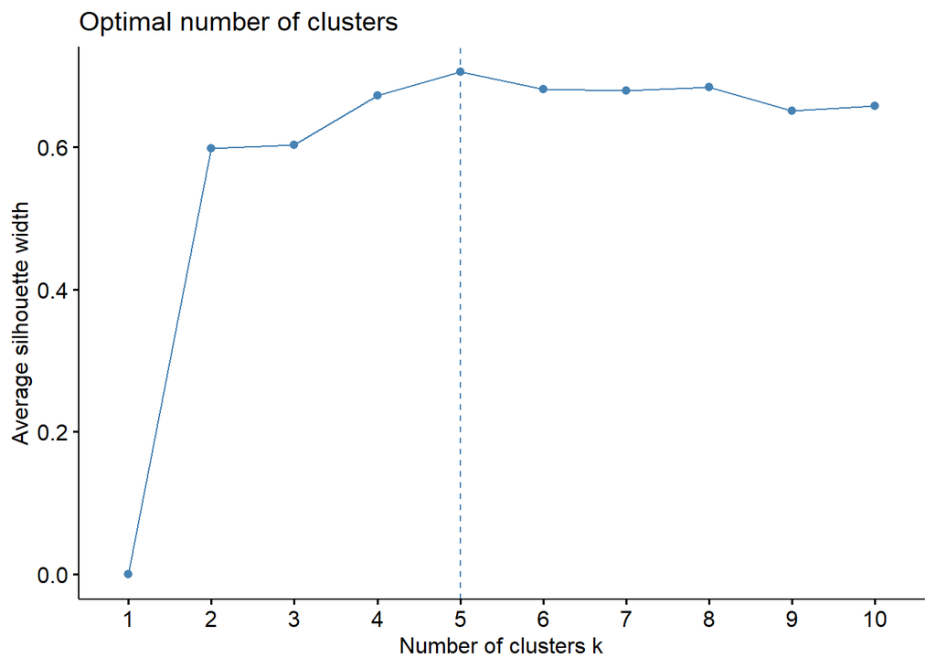

```r
# check2: pam & silhouette
fviz_nbclust(abs_df_clustering_check2, FUNcluster = pam, method = "silhouette")
```

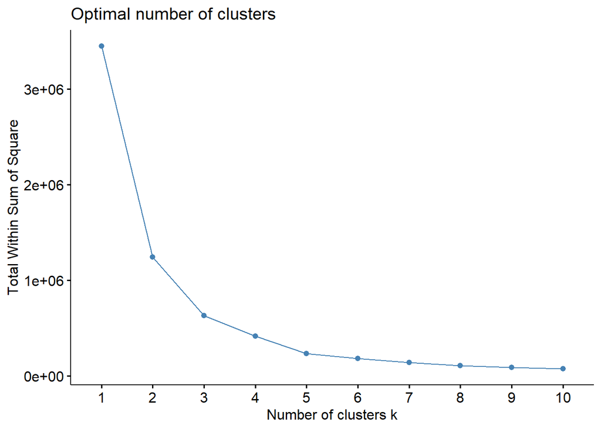

```r
# check1: Hierarchical Clustering & elbow
fviz_nbclust(abs_df_clustering_check2, FUNcluster = hcut, method = "wss")
```

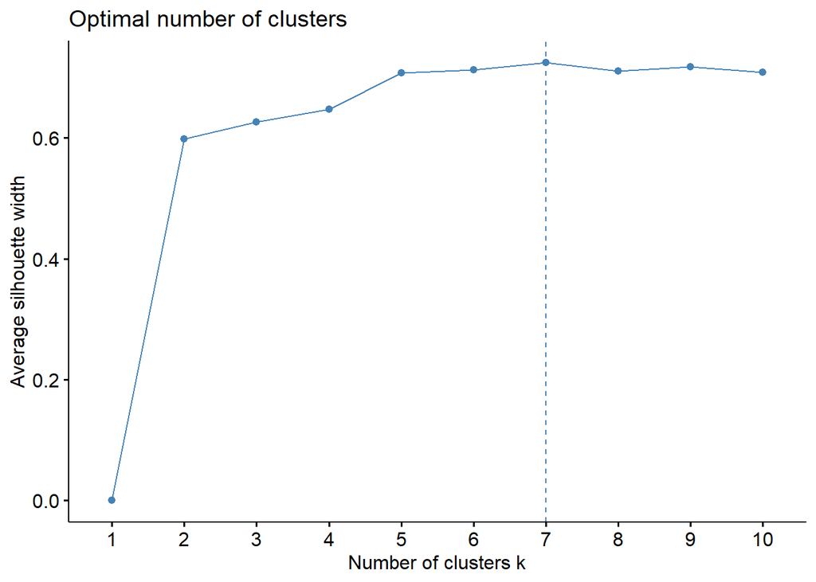

```r
# check2: Hierarchical Clustering & silhouette
fviz_nbclust(abs_df_clustering_check2, FUNcluster = hcut, method = "silhouette")
```

```r
# check3: kmeansruns & CAlinsky-Harabasz/silhouette
fit_ch  <- kmeansruns(abs_df_clustering_check2, krange = 1:15, criterion = "ch")
fit_asw <- kmeansruns(abs_df_clustering_check2, krange = 1:15, criterion = "asw")
fit_ch$bestk
```

```
## [1] 15
```

```r
fit_asw$bestk
```

```
## [1] 13
```

Dicho esto considero que un valor mas real de cantidad de cluster para analizar los datos podria llegar a ser k=3. Incluso pensemos como fuimos agrupando durante el EDA los rangos de horas de ausencia, donde en general podriamos haber agrupado las horas en no mas de 5 posibles rangos.

Grafiquemos entonces los clusters con la funcion fviz_cluster con los metodos pam como con hcut para analizarlos de manera mas visual para el set de variables correspondientes al primer grupo que vimos abs_df_clustering_check1.

El metodo pam, corresponde PAM clustering particiona los datos en k clusters alrededor de los “medoids”, el cual puede ser definido como el objeto de un grupo cuya disimilaridad media a todos los objetos en el grupo es mínima. Es el punto ubicado más hacia el centro en todo el grupo. Es más robusto ante el ruido y a partes aisladas que el clasico k-means porque minimiza una suma de disimilaridades (entre pares de puntos) en vez de una suma de distancias euclidianas cuadradas.

Mientras que el metodo hcut en R, se corresponde a lo que denominamos como Hierarchical Clustering, o Agrupamiento Jerarquico. Que es un método de análisis de grupos puntuales, el cual busca construir una jerarquía de grupos.

Veamos con mas detalle cada metodo a continuacion.

#### 3.3.5.2 PAM-Partitioning around Medoids

K-Medoids (PAM-Partitioning around Medoids) es un método de clustering muy similar a K-means en cuanto a que ambos agrupan las observaciones en K clusters, donde K es un valor preestablecido por el analista. La diferencia es que, en K-medoids, cada cluster está representado por una observación presente en el cluster (medoid), mientras que en K-means cada cluster está representado por su centroide, que se corresponde con el promedio de todas las observaciones del cluster pero con ninguna en particular.

Una definición más exacta del término medoid es: elemento dentro de un cluster cuya distancia (diferencia) promedio entre él y todos los demás elementos del mismo cluster es lo menor posible.

##### 3.3.5.2.1 Pasos del Algoritmo PAM:

1. Seleccionar K observaciones aleatorias como medoids iniciales. También es posible identificarlas de forma específica.
2. Calcular la matriz de distancia entre todas las observaciones si esta no se ha calculado anteriormente.
3. Asignar cada observación a su medoid más cercano.
4. Para cada uno de los clusters creados, comprobar si seleccionando otra observación como medoid se consigue reducir la distancia promedio del cluster, si esto ocurre, seleccionar la observación que consigue una mayor reducción como nuevo medoid.
5. Si al menos un medoid ha cambiado en el paso 4, volver al paso 3, de lo contrario, se termina el proceso.

Pasemos a ver como se comporta este algoritmo.

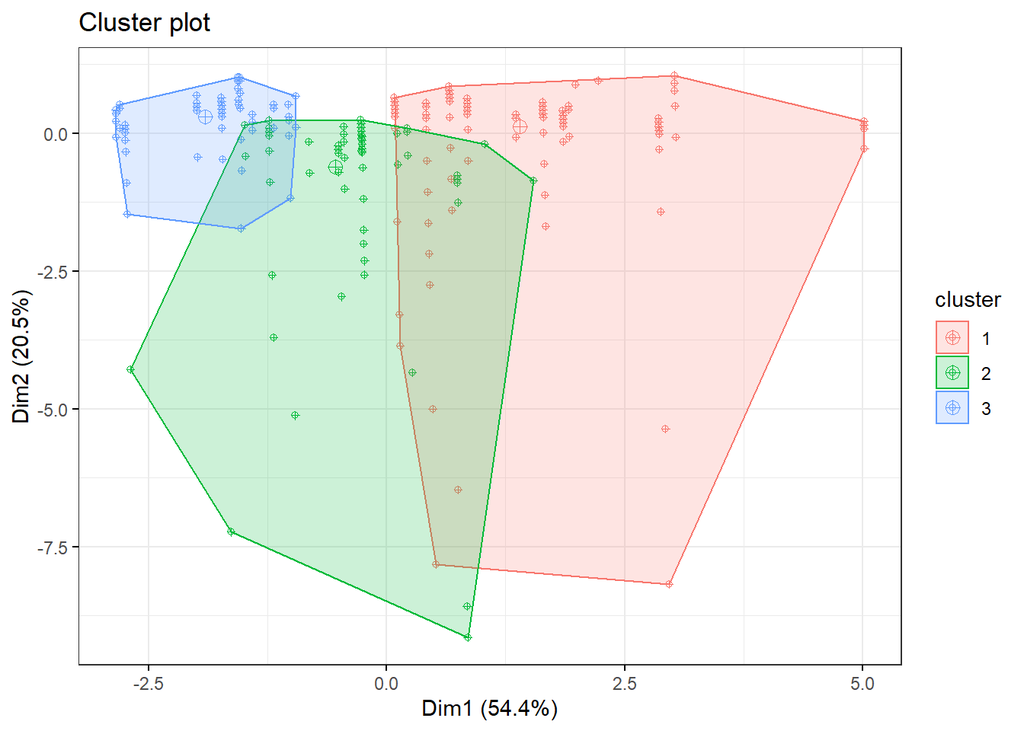

```r
set.seed(123)

# PAM Cluster with euclidean metric
abs_df_pam_euclidean <- pam(x = abs_df_clustering_check1, k = 3, metric = "euclidean")

fviz_cluster(abs_df_pam_euclidean, data  = abs_df_clustering_check1 ,
                    geom = "point",
             ellipse.type = "convex",
            show.clust.cent = TRUE,
            shape =   10,
             ggtheme = theme_bw())
```

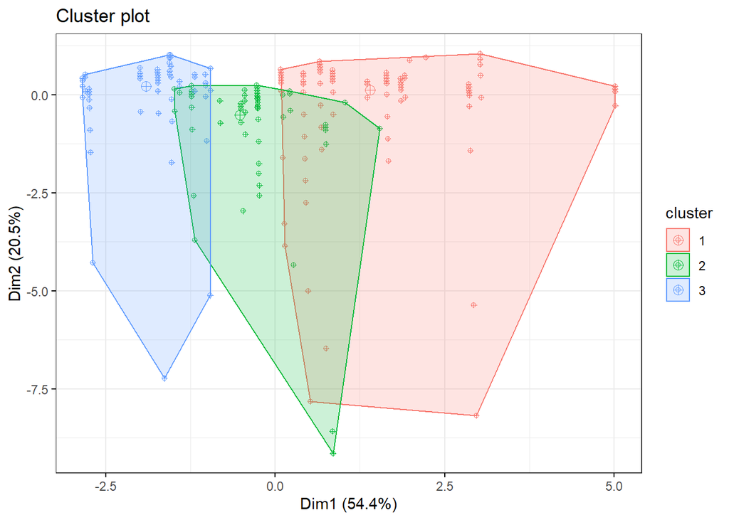

```r
# PAM Cluster with manhattan metric
abs_df_pam_manhattan<- pam(x = abs_df_clustering_check1, k = 3,  metric = "manhattan")

fviz_cluster(abs_df_pam_manhattan, data  = abs_df_clustering_check1 ,
                    geom = "point",
             ellipse.type = "convex",
            show.clust.cent = TRUE,
            shape =   10,
             ggtheme = theme_bw())
```

en cada cluster se ven outliers, seguramente haya que depurar un poco mas la informacion y/o analizar mas en profundidad estos casos o reveer la cantidad de clusters

Usamos el parametro metric para usar dos metodos, euclidean y manhattan, para calcular las distancias **around medoids**, de hecho la descripcion de este parametro es la siguiente.

El parametro **metric** es una cadena de caracteres que especifica la métrica que se utilizará para calcular las diferencias entre las observaciones. Las opciones disponibles actualmente son “euclidean” y “manhattan”. Las distancias euclidianas son la raíz de la suma de cuadrados de las diferencias, y las distancias de Manhattan son la suma de las diferencias absolutas. Si x ya es una matriz de disimilitud, este argumento se ignorara.

Pero si miramos mas la documentacon de PAM vemos que tenemos otro parametro: **stand** que es un parametro logico. Si se asigna TRUE, las medidas en x se estandarizan antes de calcular las diferencias. Las mediciones se estandarizan para cada variable, restando el valor medio de la variable y dividiendo por la desviación absoluta media de la variable. Si x ya es una matriz de disimilitud, este argumento se ignorará.

Probemos nuevamente PAM aplicando este parametro tal vez estandarizando las variables logramos hacer “mas normales” cada una de ellas y lograr mejores clusters. Veamoslo:

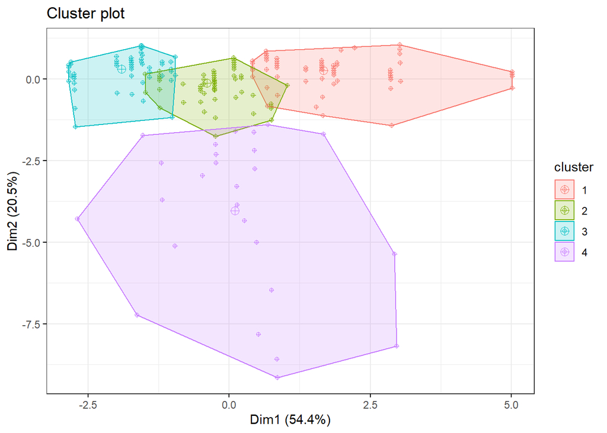

```r
set.seed(123)
# PAM Cluster with euclidean metric
abs_df_pam_euclidean_stand <- pam(x = abs_df_clustering_check1, k = 4, stand=TRUE, metric = "euclidean")

fviz_cluster(abs_df_pam_euclidean_stand, data  = abs_df_clustering_check1 ,
                    geom = "point",
             ellipse=TRUE,
             ellipse.type = "convex",
             show.clust.cent = TRUE,
             shape =   10,
             ggtheme = theme_bw())
```

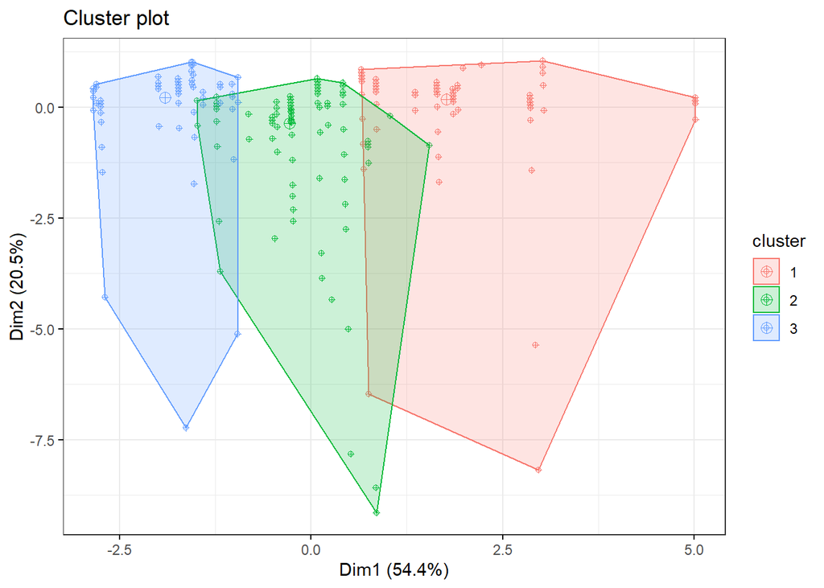

```r
# PAM Cluster with manhattan metric
abs_df_pam_manhattan_stand<- pam(x = abs_df_clustering_check1, k = 3,  stand=TRUE, metric = "manhattan")

fviz_cluster(abs_df_pam_manhattan_stand, data  = abs_df_clustering_check1 ,
                    geom = "point",
             ellipse=TRUE,
             ellipse.type = "convex",
            show.clust.cent = TRUE,
            shape =   10,
             ggtheme = theme_bw())
```

En estas 4 ejecucion que hemos hecho de PAM con las diferentes metricas, visualmente vemos mas definidos los clusters cuando se estandarizo las variables. Por lo que nos quedaremos con estas dos ultimas variables para el posterior conclusion final.

#### 3.3.5.3 Agglomerative Hierarchical Clustering

En esta sección vamos a realizar el proceso de clusterizado utilizando Hierarchical Clustering. El algoritmo funciona de la siguiente forma:

##### 3.3.5.3.1 Pasos del Algoritmo:

1. Cada registro del dataset empieza generando su propio cluster, por lo que nos encontramos con tantos clusteres como elementos queramos procesar.
2. Se aplica una función para comprobar cual es la semejanda y afinidad entre los diferentes clusteres (se suele usar la distancia euclidea). Aquellos que se consideran parecidos son fusionados.
3. Se sigue aplicando el algoritmo hasta que se llega al número de clusteres indicado.

Pasemos a ver como se comporta este algoritmo.

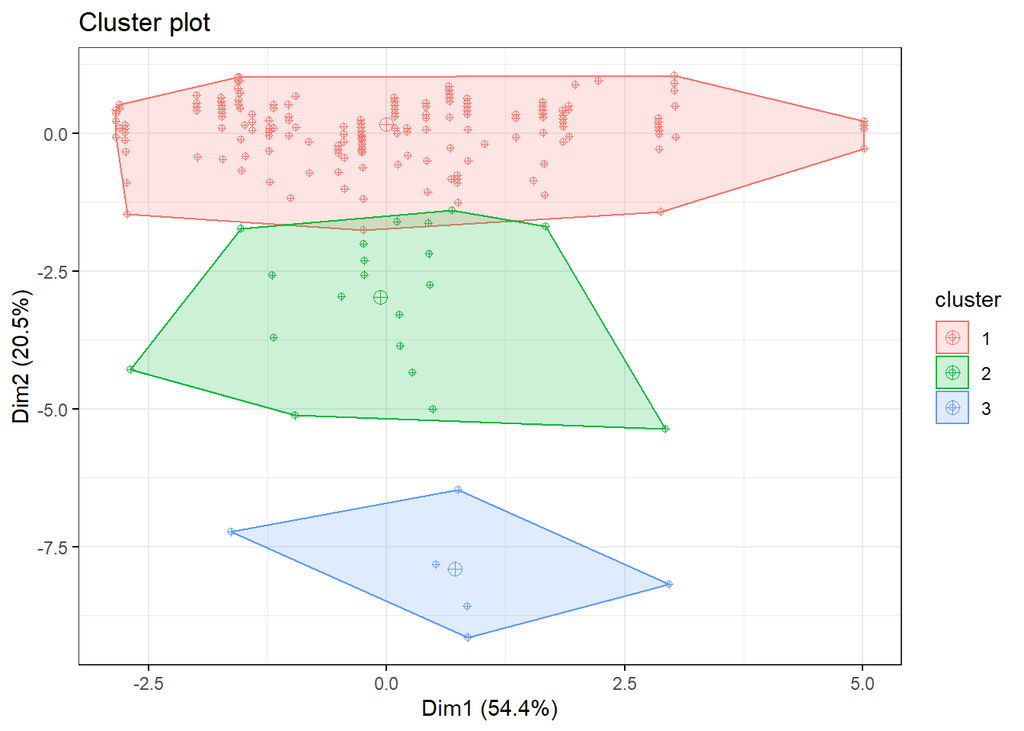

```r
set.seed(123)

# HClustering  with euclidean metric
abs_df_hcut_euclidean_k3=hcut(x=abs_df_clustering_check1,k=3,hc_method="complete",hc_metric='euclidean')


fviz_cluster(abs_df_hcut_euclidean_k3, data=abs_df_clustering_check1 ,
              geom = "point",
              ellipse.type = "convex",
              show.clust.cent = TRUE,
              shape =   10,
              ggtheme = theme_bw())
```

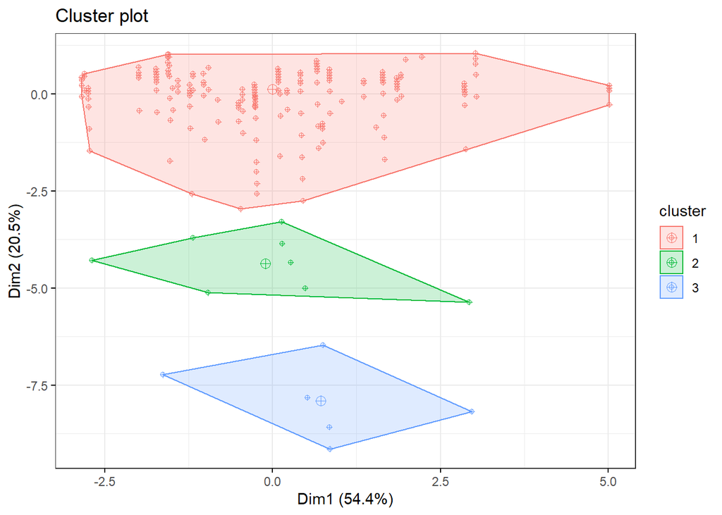

```r
# HClustering with manhattan metric
abs_df_hcut_manhattan_k3=hcut(x=abs_df_clustering_check1,k=3,hc_method="complete",hc_metric='manhattan')

fviz_cluster(abs_df_hcut_manhattan_k3, data=abs_df_clustering_check1 ,
              geom = "point",
              ellipse.type = "convex",
              show.clust.cent = TRUE,
              shape =   10,
              ggtheme = theme_bw())
```

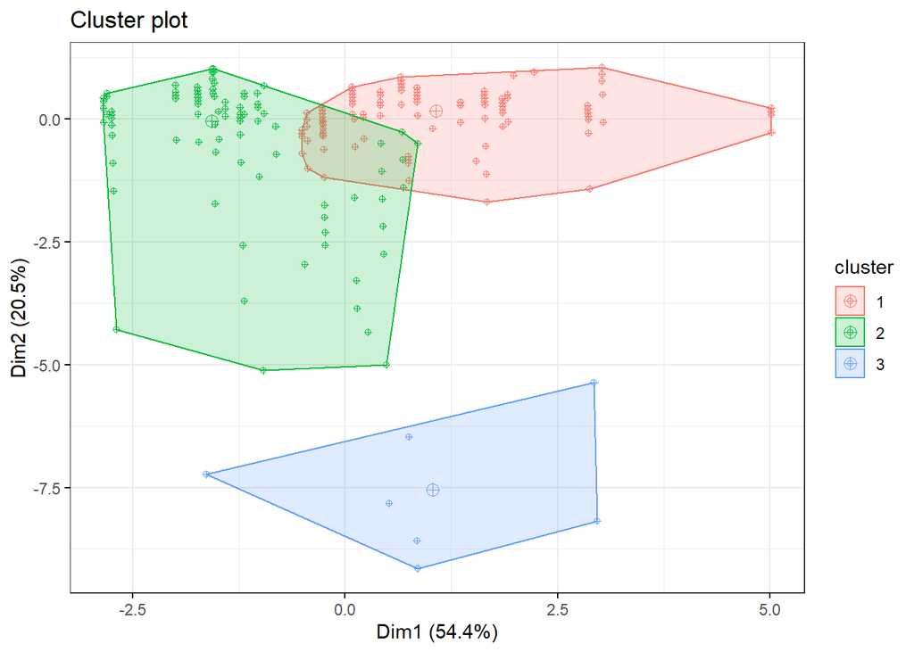

```r
#---------------------------------------

# HClustering  with euclidean metric
abs_df_hcut_euclidean_stand_k3=hcut(x=abs_df_clustering_check1,k=3,hc_method="complete",hc_metric='euclidean',stand=TRUE)


fviz_cluster(abs_df_hcut_euclidean_stand_k3, data=abs_df_clustering_check1 ,
              geom = "point",
              ellipse.type = "convex",
              show.clust.cent = TRUE,
              shape =   10,
              ggtheme = theme_bw())
```

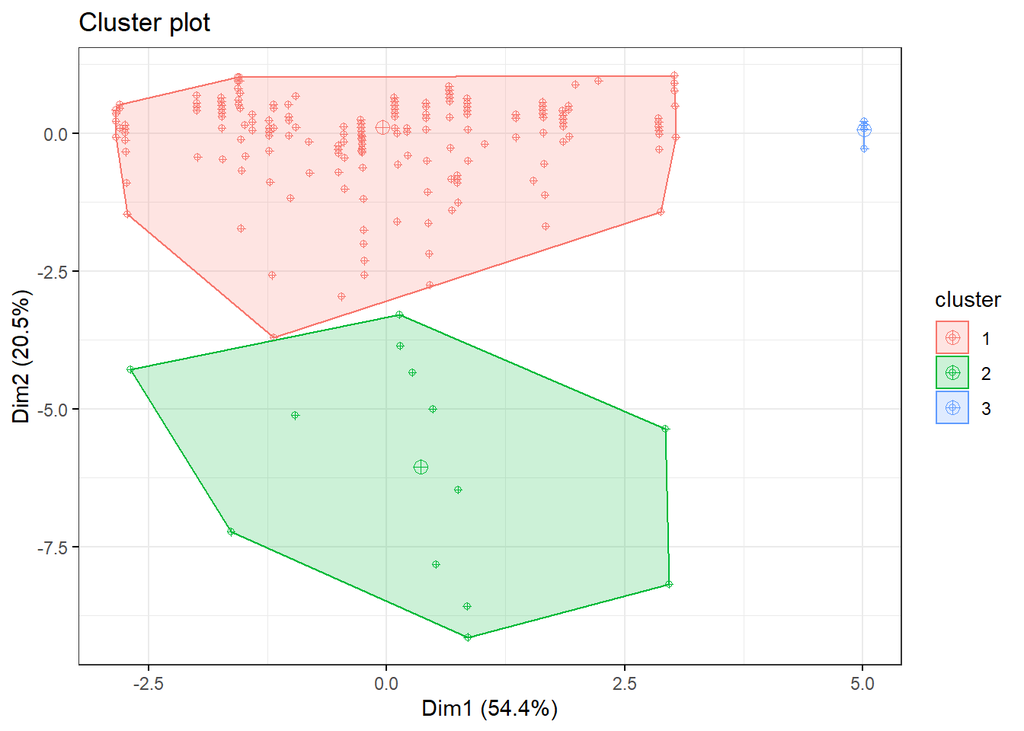

```r
# HClustering with manhattan metric
abs_df_hcut_manhattan_stand_k3=hcut(x=abs_df_clustering_check1,k=3,hc_method="complete",hc_metric='manhattan',stand=TRUE)

fviz_cluster(abs_df_hcut_manhattan_stand_k3, data=abs_df_clustering_check1 ,
              geom = "point",
              ellipse.type = "convex",
              show.clust.cent = TRUE,
              shape =   10,
              ggtheme = theme_bw())
```

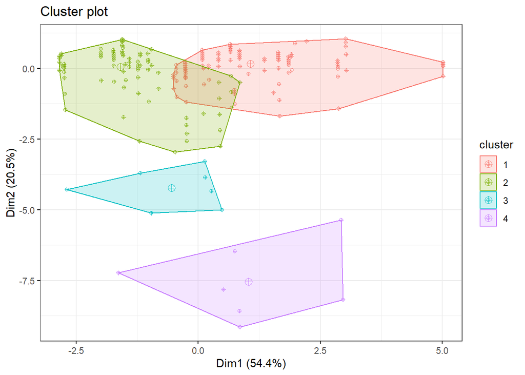

```r
#---------------------------------------

# HClustering  with euclidean metric
abs_df_hcut_euclidean_stand_k4=hcut(x=abs_df_clustering_check1,k=4,hc_method="complete",hc_metric='euclidean',stand=TRUE)


fviz_cluster(abs_df_hcut_euclidean_stand_k4, data=abs_df_clustering_check1 ,
              geom = "point",
              ellipse.type = "convex",
              show.clust.cent = TRUE,
              shape =   10,
              ggtheme = theme_bw())
```

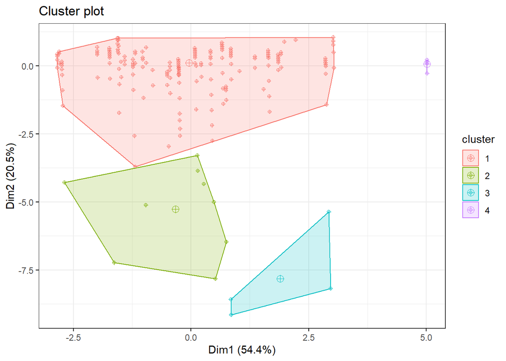

```r
# HClustering with manhattan metric
abs_df_hcut_manhattan_stand_k4=hcut(x=abs_df_clustering_check1,k=4,hc_method="complete",hc_metric='manhattan',stand=TRUE)

fviz_cluster(abs_df_hcut_manhattan_stand_k4, data=abs_df_clustering_check1 ,
              geom = "point",
              ellipse.type = "convex",
              show.clust.cent = TRUE,
              shape =   10,
              ggtheme = theme_bw())
```

### 3.3.6 Conclusiones

Luego de haber aplicado tanto pam, como hcut, con diferentes valores de K, con diferentes metricas (euclidean y manhattan) y estandarizando o no las variables, vemos que con k=3 se definen bien los clusters. Aunque si debemos decir que con hcut los clusters estan mucho mas marcados que con pam, y hasta incluso podemos generar 4 clusters bien independientes.

Para analizar el resultado de haber aplicado estos algoritmos no supervisados y entender las caracteristicas de cada cluster para cada uno de los metodos aplicados podemos haer uso de la funcion aggragate como vemos aqui:

```r
# Para abs_df_pam_euclidean_stand con k=4
aggregate(abs_df_clustering_check1,by=list(abs_df_pam_euclidean_stand$cluster),mean)
```

```
##   Group.1 Absenteeism.time.in.hours   Weight      Age Body.mass.index
## 1       1                  4.607639 91.72917 39.90625        30.92014
## 2       2                  5.154930 71.96244 38.86385        24.53991
## 3       3                  4.488152 68.80095 29.04265        23.18483
## 4       4                 62.571429 79.39286 38.35714        25.60714
##   Service.time
## 1     16.10069
## 2     12.50704
## 3      7.71564
## 4     12.89286
```

```r
# Para abs_df_pam_manhattan_stand con k=3
aggregate(abs_df_clustering_check1,by=list(abs_df_pam_manhattan_stand$cluster),mean)
```

```
##   Group.1 Absenteeism.time.in.hours   Weight      Age Body.mass.index
## 1       1                  5.915129 91.63469 40.31365        31.39483
## 2       2                  8.968504 74.25591 38.59449        24.59055
## 3       3                  5.781395 68.80000 29.04651        23.19535
##   Service.time
## 1    16.195572
## 2    12.755906
## 3     7.725581
```

Vemos que para el primer grupo de clusters con PAM, tenemos los 3 primero con caracteristicas bastantes similares ya para el rango de edad comprendido entre los 29 y 39 años, y con un BMI entre los 23 y 30, cuya mayoria esta formada por gente con sobrepeso, la cantidad de horas de ausencia rondaria de 4 a 5 horas. Mientras que el 4to cluster es bastante distintivo ya que agrupa el personal que se ausentaria mas de 50hs pero con caracteristicas simialres a los otros 3 cluster por lo que es bastante extraña esta agrupacion.

El 2do grupo de clusters con PAM, tiene la particularidad haber separado en clusters de 5 y 8 horas de ausentismo, la diferencia esta dada por la diferencia de edad mayores y menores de 30 años y BMI que indican peso normal o sobrepeso.

Veamos ahora lo que obtuvimos con Hcut y validemos si los clusters visualmente mejor definidos se traducen en caracteristicas mas distintivas y claras:

```r
# Para abs_df_hcut_manhattan_k3
aggregate(abs_df_clustering_check1,by=list(abs_df_hcut_manhattan_k3$cluster),mean)
```

```
##   Group.1 Absenteeism.time.in.hours   Weight      Age Body.mass.index
## 1       1                  5.360882 79.03168 36.38292        26.69835
## 2       2                 68.000000 78.37500 37.25000        25.50000
## 3       3                114.666667 80.33333 43.50000        25.66667
##   Service.time
## 1     12.54408
## 2     12.12500
## 3     14.33333
```

```r
# Para abs_df_hcut_manhattan_stand_k3
aggregate(abs_df_clustering_check1,by=list(abs_df_hcut_manhattan_stand_k3$cluster),mean)
```

```
##   Group.1 Absenteeism.time.in.hours    Weight      Age Body.mass.index
## 1       1                  5.445983  78.81163 36.29501        26.62881
## 2       2                 90.461538  80.30769 40.23077        25.76923
## 3       3                  3.200000 108.00000 49.00000        36.00000
##   Service.time
## 1     12.42798
## 2     13.23077
## 3     29.00000
```

```r
# Para abs_df_hcut_manhattan_stand_k4
aggregate(abs_df_clustering_check1,by=list(abs_df_hcut_manhattan_stand_k4$cluster),mean)
```

```
##   Group.1 Absenteeism.time.in.hours    Weight      Age Body.mass.index
## 1       1                  5.445983  78.81163 36.29501        26.62881
## 2       2                 82.666667  79.77778 34.11111        25.44444
## 3       3                108.000000  81.50000 54.00000        26.50000
## 4       4                  3.200000 108.00000 49.00000        36.00000
##   Service.time
## 1     12.42798
## 2     11.55556
## 3     17.00000
## 4     29.00000
```

Como vemos en los 3 grupos de clusters obtenidos con hcut, las caracteristicas de cada clusters dentro de cada grupo son bien distintivas. Vemos para los 3 grupos que en general se obtienen rangos tiempos de ausentismo menores a 4 horas, de 4 a 8, de mas de 1 semana, y hasta 2 semanas de ausencias, teniendo en cuenta horas laborables de jornadas de 8hs. Y en general vemos que los que menos se ausentan tienen un valor elevado de service time, estan en su adultez y con un BMI que indica obesidad. En contrapartida con los clusteres que se ausentan mas que tienen casi un BMI que comienza a decrece y un service time cercano a la mediana.

Dicho todo esto pasemos a la construccion de un modelo que nos permita predecir todo esto que fuimos analizando hasta ahora a partir de la exploracion de los datos.

## 3.4 Construccion del modelo

Para construir un modelo que nos permite predecir las horas de ausentismo deberemos primero que nada generar dos set de datos uno para efectivamente construir y entrenar el modelo y un segudo set de datos para validar ese mismo modelo.

### 3.4.1 Generacion de dataset de training y testing

Con la función sample_frac de dplyr generamos una muestra aleatoria de nuestro dataset, donde crearemos el dataset de train especificando la proporción del dataset original que queremos, y finalmente asignaremos al dataset de test el resto de las filas que no han estado seleccionadas con la función anti_join. Esta division es necesaria para la posterior validacion de nuestro modelo. Es por eso que necesitamos tener dos conjuntos, el de entrenamiento y el de prueba.

En primer instancia construyamos un modelo a partir de todas la variables disponibles en el dataset original previo a haber agregado variables descriptivas, haber discretizado o aplicado PCA, y chequemos el resultado.

Es por eso que arranquemos generando los dos set de datos para ese primer objetivo:

```r
set.seed(123)
#colnames(abs_df)

rows <- 1:nrow(abs_df)
abs_df <- abs_df %>% mutate(rowID = rows)

train <- sample_frac(abs_df[rows,], .75)
test  <-   anti_join(abs_df[rows,], train, by='rowID')

# Datasets de entrenamiento
training_x <- train[,c(2:20)]
training_y <- train$absenteeism_range

# Datasets de validacion
testing_x <- test[,c(2:20)]
testing_y <- test$absenteeism_range
```

### 3.4.2 Creacion del modelo y extraccion de reglas

Se crea el árbol de decisión usando los datos de entrenamiento.

```r
set.seed(123)
training_y = as.factor(training_y)
#training_x = as.factor(training_x)
abs_model <- C50::C5.0(training_x, training_y, rules=TRUE )


print(abs_model)
```

```
##
## Call:
## C5.0.default(x = training_x, y = training_y, rules = TRUE)
##
## Rule-Based Model
## Number of samples: 555
## Number of predictors: 19
##
## Number of Rules: 27
##
## Non-standard options: attempt to group attributes
```

```r
summary(abs_model)
```

```
##
## Call:
## C5.0.default(x = training_x, y = training_y, rules = TRUE)
##
##
## C5.0 [Release 2.07 GPL Edition]      Wed Jan 13 22:59:22 2021
## -------------------------------
##
## Class specified by attribute `outcome'
##
## Read 555 cases (20 attributes) from undefined.data
##
## Rules:
##
## Rule 1: (4/1, lift 33.6)
##  Reason.for.absence <= 22
##  Month.of.absence > 11
##  Distance.from.Residence.to.Work <= 16
##  ->  class + 40 h  [0.667]
##
## Rule 2: (4/2, lift 25.2)
##  Reason.for.absence <= 22
##  Age > 53
##  ->  class + 40 h  [0.500]
##
## Rule 3: (32, lift 16.3)
##  Reason.for.absence <= 0
##  ->  class 0 h  [0.971]
##
## Rule 4: (16, lift 1.9)
##  Reason.for.absence > 26
##  Month.of.absence > 8
##  Body.mass.index > 25
##  ->  class 1-3 h  [0.944]
##
## Rule 5: (32/1, lift 1.9)
##  Reason.for.absence > 26
##  Seasons <= 2
##  Social.drinker > 0
##  Body.mass.index > 25
```

[output cut: 183 more lines]

```
##   29.01% Work.load.Average.day.
##   28.65% Social.smoker
##   22.70% Seasons
##   21.44% Body.mass.index
##   20.54% Age
##   20.18% Service.time
##   15.32% Education
##   13.51% Pet
##    3.96% Transportation.expense
##    3.96% Height
##    3.42% Distance.from.Residence.to.Work
##    1.98% Day.of.the.week
##
##
## Time: 0.0 secs
```

Vemos que al usar el dataset original donde tenemos la variable **Razon de ausencia** muchas reglas con esta variables son obvias e introducen ruido en las posibles reglas o mejor dicho c5.0 la variable mas important para comenzar la clasificacion. Decimos que nos agrega ruido, ya que sabemos que si hay una razon es claro q habra una cantidad de horas de ausencia,… pero que pasa si queremos predecir en base al comportamiento o caracteristicas del empleado si faltara y en que rango de horas, no tiene sentido usar esa variable porque seguramente la cantidad de horas de ausencia puede estar relacionada casi directamente al tipo de motivo medico de la consulta medica o padecimiento del empleado. Aunque claro podriamos tambien hacer foco en este punto y segun el padecimiento o tipo de consulta medica sabriamos que faltara cierta cantidad de tiempo. O incluso podriamos hacer foco, en el padecimiento y entender un poco que reglas se pueden obtener o incluso solo analizar el reason “consulta medica” que parece bastante generico y con ese filtrado obtener reglas, etc… hay varias opciones de analizar. Pero en este caso queremos determinar u obtener reglas mas alla de la consulta, sino mas bien focaliar en las caracteristicas de la persona y comportamiento.

Asi que repitamos el proceso pero sin la razon de ausencia.

```r
set.seed(123)

abs_df <- abs_df %>% filter(!Month.of.absence==0)
rows <- 1:nrow(abs_df)
abs_df <- abs_df %>% mutate(rowID = rows)

train <- sample_frac(abs_df[rows,], .75)
test  <-   anti_join(abs_df[rows,], train, by='rowID')


# Datasets de entrenamiento
training_x <- train[,c(3:20)]
training_y <- train$absenteeism_range

# Datasets de validacion
testing_x <-   test[,c(3:20)]
testing_y <-   test$absenteeism_range

training_y = as.factor(training_y)
abs_model <- C50::C5.0(training_x , training_y, rules=TRUE )

summary(abs_model)
```

```
##
## Call:
## C5.0.default(x = training_x, y = training_y, rules = TRUE)
##
##
## C5.0 [Release 2.07 GPL Edition]      Wed Jan 13 22:59:22 2021
## -------------------------------
##
## Class specified by attribute `outcome'
##
## Read 553 cases (19 attributes) from undefined.data
##
## Rules:
##
## Rule 1: (30, lift 17.3)
##  Disciplinary.failure > 0
##  ->  class 0 h  [0.969]
##
## Rule 2: (8, lift 1.9)
##  Month.of.absence <= 6
##  Seasons <= 1
##  Social.drinker <= 0
##  ->  class 1-3 h  [0.900]
##
## Rule 3: (5, lift 1.8)
##  Month.of.absence > 8
##  Seasons <= 1
##  Social.drinker <= 0
##  ->  class 1-3 h  [0.857]
##
## Rule 4: (59/13, lift 1.6)
##  Month.of.absence <= 2
##  Day.of.the.week > 2
##  Age <= 38
##  ->  class 1-3 h  [0.770]
##
## Rule 5: (39/9, lift 1.6)
##  Month.of.absence <= 10
##  Education > 2
##  Weight <= 80
```

[output cut: 129 more lines]

```
##   25.68% Age
##   20.43% Education
##   15.91% Height
##    7.96% Son
##    7.96% Social.drinker
##    7.05% Weight
##    5.79% Seasons
##    5.61% Social.smoker
##    3.07% Distance.from.Residence.to.Work
##    3.07% Work.load.Average.day.
##    1.63% Pet
##    1.08% Service.time
##
##
## Time: 0.0 secs
```

```r
print(abs_model)
```

```
##
## Call:
## C5.0.default(x = training_x, y = training_y, rules = TRUE)
##
## Rule-Based Model
## Number of samples: 553
## Number of predictors: 18
##
## Number of Rules: 18
##
## Non-standard options: attempt to group attributes
```

Antes de describir las reglas pintemos el arbol y veamos que tal se ve.

[figure not shown]

```r
set.seed(20)
training_y = as.factor(training_y)
abs_model <- C50::C5.0(training_x, training_y )


plot(abs_model)
```

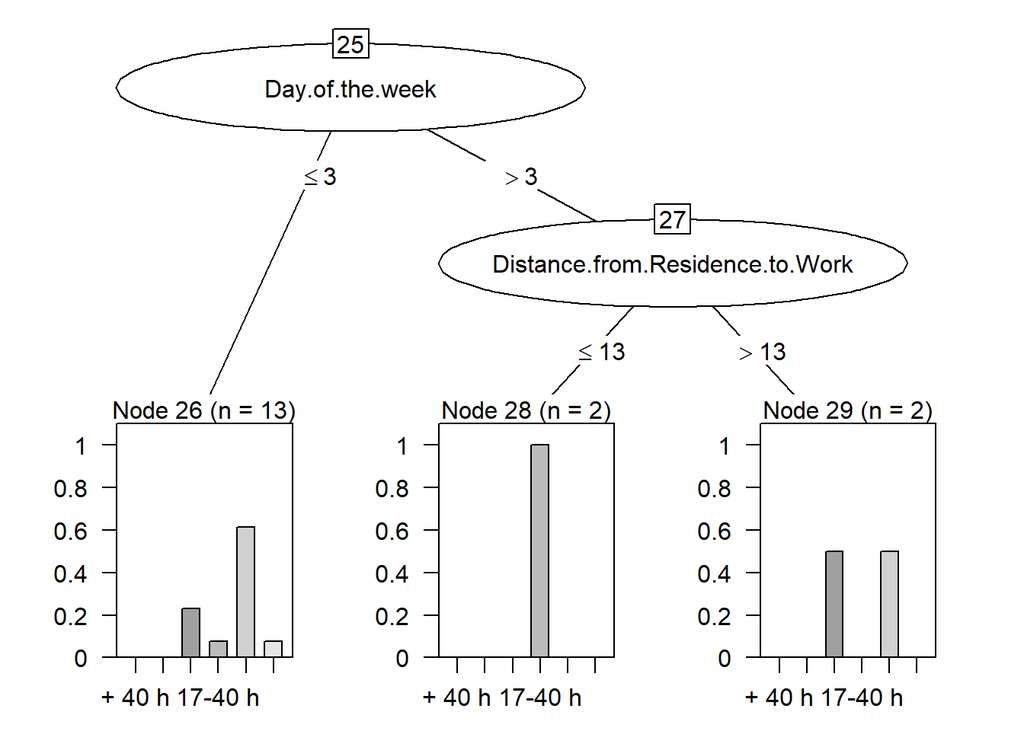

```r
# dada la cantidad de nodos y ramas, es mejor analizarlo filtrando los niveles o subrarboles. En casos asi es incluso es mas claro ver directamente las reglas o usar otro tipo de grafica mas que un simple plot.
plot(abs_model, subtree = 25)
```

Las reglas que obtuvimos a partir de nuestros datos fueron 18, describamos aqui las primeras 5 con mayor lift:

Al parecer los que posee un fallo disciplinario no se ausentan? esta es la primer regla?.. En un proceso de dataming real claramente volveriamos atras o aqui mismo deberiamos analizar estos datos. Pero bueno si el modelo esta funcionando a partir del dataset lo podemos pensar como que el que tuvo un fallo disciplinario y fue alertado por eso, no quiera o no tenga intencion de ausentar por temor a algun otro tipo de represalia.

Rule 2: (8, lift 1.9) Month.of.absence <= 6 Seasons <= 1 Social.drinker <= 0 -> class 1-3 h

Rule 3: (5, lift 1.8) Month.of.absence > 8 Seasons <= 1 Social.drinker <= 0 -> class 1-3 h [0.857]

Rule 4: (59/13, lift 1.6) Month.of.absence <= 2 Day.of.the.week > 2 Age <= 38 -> class 1-3 h [0.770]

Rule 5: (39/9, lift 1.6) Month.of.absence <= 10 Education > 2 Weight <= 80 -> class 1-3 h [0.756]

El mismo rango de horas suelen ausentarse las personas menores de 38 años con un peso menor a 80kg, en cualquier momento del año.

## 3.5 Evaluacion del modelo

Si bien las primeras 5 reglas no nos dicen mucho veamos esta poca eficiencia en numeros evaluando el modelo. En principio lo haremos con el modelo tal como lo construimos en el step anterior, con los datos originales. Osea sin aplicar PCA.

### 3.5.1 sin PCA

Validemos ahora el modelo obtenido en el paso anterior:

```r
predicted_model <- predict(abs_model, testing_x , type="class")

# Donde la precision promedio del modelo es:
print(sprintf("La precisión del árbol es: %.4f %%",100*sum(predicted_model == testing_y) / length(predicted_model)))
```

```
## [1] "La precisión del árbol es: 63.0435 %"
```

Analicemos los verdaderos positivos y verdaderos negativos, y la sensibilidad a partir de las matrices de confusion:

```r
library(gmodels)
CrossTable(testing_y, predicted_model,prop.chisq  = FALSE, prop.c = FALSE, prop.r =FALSE,dnn = c('Reality', 'Prediction'))
```

```
##
##
##    Cell Contents
## |-------------------------|
## |                       N |
## |         N / Table Total |
## |-------------------------|
##
##
## Total Observations in Table:  184
##
##
##              | Prediction
##      Reality |    + 40 h |       0 h |     1-3 h |   17-40 h |     4-8 h | Row Total |
## -------------|-----------|-----------|-----------|-----------|-----------|-----------|
##       + 40 h |         1 |         0 |         2 |         1 |         2 |         6 |
##              |     0.005 |     0.000 |     0.011 |     0.005 |     0.011 |           |
## -------------|-----------|-----------|-----------|-----------|-----------|-----------|
##          0 h |         0 |        10 |         0 |         0 |         0 |        10 |
##              |     0.000 |     0.054 |     0.000 |     0.000 |     0.000 |           |
## -------------|-----------|-----------|-----------|-----------|-----------|-----------|
##        1-3 h |         0 |         0 |        74 |         1 |        16 |        91 |
##              |     0.000 |     0.000 |     0.402 |     0.005 |     0.087 |           |
## -------------|-----------|-----------|-----------|-----------|-----------|-----------|
##      17-40 h |         1 |         0 |         3 |         0 |         5 |         9 |
##              |     0.005 |     0.000 |     0.016 |     0.000 |     0.027 |           |
## -------------|-----------|-----------|-----------|-----------|-----------|-----------|
##        4-8 h |         3 |         0 |        28 |         2 |        31 |        64 |
##              |     0.016 |     0.000 |     0.152 |     0.011 |     0.168 |           |
## -------------|-----------|-----------|-----------|-----------|-----------|-----------|
##       9-16 h |         0 |         0 |         2 |         0 |         2 |         4 |
##              |     0.000 |     0.000 |     0.011 |     0.000 |     0.011 |           |
## -------------|-----------|-----------|-----------|-----------|-----------|-----------|
## Column Total |         5 |        10 |       109 |         4 |        56 |       184 |
## -------------|-----------|-----------|-----------|-----------|-----------|-----------|
##
##
```

### 3.5.2 con PCA

Pero que pasaria si ahora contruimos un modelo sobre nuestros datos pero luego de haber aplicado PCA.

Como ya hemos calculado todas las componentes principales, y las tenemos en el objeto “pca” podemos acceder a la componenente 1 de la siguiente forma, por lo que utilizaremos esta variables para contruir un modelo mediante arboles de decision, entrenarlo y luego validarlo.

```r
set.seed(123)

# Agregamos la variable objetivo de nuevo a los datos rotados generados por PCA anteriormente
pca <- prcomp(abs_df[,2:20], scale = TRUE)
pca_and_target_data=data.frame(absenteeism_range=abs_df$absenteeism_range, pca$x)

# nos quedamos con la variable objetivo y las primeras 10 componentes ppales que representan el 80% de la varianza de los datos.
pca_PC10 = pca_and_target_data[,1:9]

#--------------------------------------------------------

rows <- 1:nrow(pca_PC10)
pca_PC10 <- pca_PC10 %>% mutate(rowID = rows)

train <- sample_frac(pca_PC10[rows,], .75)
test  <-   anti_join(pca_PC10[rows,], train, by='rowID')


# Nos quedamos con la variables mas representativas para contruir el modelo y obtener reglas
# Datasets de entrenamiento
training_x <- train[,c(2:9)]
training_y <- train$absenteeism_range

# Datasets de validacion
testing_x <-   test[,c(2:9)]
testing_y <-   test$absenteeism_range

training_y = as.factor(training_y)
abs_pca_model <- C50::C5.0(training_x , training_y )


print(abs_pca_model)
```

```
##
## Call:
## C5.0.default(x = training_x, y = training_y)
##
## Classification Tree
## Number of samples: 553
## Number of predictors: 8
##
## Tree size: 45
##
## Non-standard options: attempt to group attributes
```

```r
summary(abs_pca_model)
```

```
##
## Call:
## C5.0.default(x = training_x, y = training_y)
##
##
## C5.0 [Release 2.07 GPL Edition]      Wed Jan 13 22:59:27 2021
## -------------------------------
##
## Class specified by attribute `outcome'
##
## Read 553 cases (9 attributes) from undefined.data
##
## Decision tree:
##
## PC3 > 2.054926:
## :...PC4 <= 1.102044:
## :   :...PC6 <= 0.2961949: 0 h (29)
## :   :   PC6 > 0.2961949: 1-3 h (2/1)
## :   PC4 > 1.102044:
## :   :...PC7 <= 0.1234038: 1-3 h (3/1)
## :       PC7 > 0.1234038: 4-8 h (3)
## PC3 <= 2.054926:
## :...PC2 <= -1.233663:
##     :...PC3 <= 0.5930371: 4-8 h (90/27)
##     :   PC3 > 0.5930371:
##     :   :...PC5 <= -0.1939957: 4-8 h (6/1)
##     :       PC5 > -0.1939957:
##     :       :...PC2 <= -2.519275: 0 h (2/1)
##     :           PC2 > -2.519275: 17-40 h (4)
##     PC2 > -1.233663:
##     :...PC4 <= -0.4514538:
##         :...PC7 <= -0.6419252:
##         :   :...PC5 <= 2.467202: 1-3 h (37/15)
##         :   :   PC5 > 2.467202:
##         :   :   :...PC1 <= -1.10354: 4-8 h (2/1)
##         :   :       PC1 > -1.10354: + 40 h (2/1)
##         :   PC7 > -0.6419252:
##         :   :...PC3 <= 0.918829:
##         :       :...PC3 <= -1.628727: 1-3 h (6)
##         :       :   PC3 > -1.628727: 4-8 h (59/24)
```

[output cut: 87 more lines]

```
##
##
##  Attribute usage:
##
##  100.00% PC3
##   93.31% PC2
##   81.56% PC4
##   32.37% PC6
##   28.75% PC1
##   23.69% PC8
##   22.78% PC7
##   20.07% PC5
##
##
## Time: 0.0 secs
```

```r
predicted_pca_model <- predict(abs_pca_model, testing_x , type="class")

# Donde la precision promedio del modelo es:
print(sprintf("La precisión del árbol es: %.4f %%",100*sum(predicted_pca_model == testing_y) / length(predicted_pca_model)))
```

```
## [1] "La precisión del árbol es: 63.5870 %"
```

### 3.5.3 Conclusiones:Capacidad Predictiva c/PCA vs s/PCA

En nuestro caso al aplicar arboles de decision post aplicacion PCA obtuvimos una mejora casi nula en la precision del arbol, otra alternativa aqui podria ser aplicar alguna tecnica de poda, ya sea con o sin PCA para lograr una mayor eficiencia.

Dado que nuestro dataset es muy pequeño se pueden seguir probando otros algoritmos para ver la posibilidad si conseguimos una mejor precision, ya sea con o sin PCA. O mismo se podria cambiar la estrategia de haber armado rangos horarios a predecir, ya que podriamos haber considerado las horas de ausencia como una variabel dependiente continua y haber aplicado regresion lineal. Son varias las alternativas segun la estrategia seleccionada. Ademas de que no siempre, creo yo, no hay que enfocarse en unico algoritmo predictivo, mas a un como en este caso donde el costo computacional de ejecutar n algoritmos es nulo dado el tamaño del dataset. Asi que podriamos volver a etapas anteriores de nuestro mini proyecto de datamining y arrancar con otras estrategias y aplicando los mismos u otras tecnicas.

## 3.6 Integracion: Responda al objetivo

Mas alla de que nuestro modelo, tal como lo hemos analizado y con la estrategia elegida, tiene solo una precision de 63% es igualmente util para extraer algunos insights que nos permitan establecer reglas de negocio en un sistema **X**.

Por ejemplo en la plataforma Microstrategy, se podrian generar dashboards con una metrica que posean embebido nuestro modelo R y por ende nos vaya graficando como performa la metrica a partir de la carga diaria de datos al datawarehouse corporativo y recalcularse para permitir a los analistas ver la evolucion del modelo.

Esta primer iteracion permitiria entonces dar un primer paso para entender los datos y la performance del modelo, y luego si con mas “indicios o pistas” poder realizar una segunda iteracion del proyecto y focalizar en una estrategia o algoritmo particular.

# 4 Rúbrica

- 10%. Trata todos los puntos de la práctica como un proyecto real de minería de datos, siguiendo todos los puntos del ciclo de vida, desde la descripción funcional hasta la integración de los resultados, comentando los puntos en los que sería necesario volver atrás cuando sea necesario.
- 15%. Se generan reglas y se comentan e interpretan las más significativas. Adicionalmente se genera matriz de confusión para medir la capacidad predictiva del algoritmo.
- 15%. Se genera modelo no supervisado, se muestran y comentan medidas de calidad del modelo generado y se comentan las conclusiones.
- 15%. Se genera modelo no supervisado con métrica de distancia distinta al anterior. Se muestran y comentan medidas de calidad del modelo generado y se comentan las conclusiones. Adicionalmente se comparan los dos modelos no supervisados con métricas de distancia distinta.
- 15%. Se genera un modelo supervisado sin PCA/SVD previo, se muestran y comentan medidas de calidad del modelo generado y se comenta extensamente el conocimiento extraído del modelo.
- 15%. Se genera un modelo supervisado con PCA/SVD previo, se muestran y comentan medidas de calidad del modelo generado y se comenta extensamente el conocimiento extraído del modelo.
- 15%. Se compara la capacidad predictiva de los dos modelos supervisados y se comenta la diferencia de rendimiento en base al efecto PCA/SVD.

# 5 Recursos de programación

- Incluimos en este apartado una lista de recursos de programación para minería de datos donde podréis encontrar ejemplos, ideas e inspiración:
  - [Material adicional del libro: Minería de datos Modelos y Algoritmos](http://oer.uoc.edu/libroMD/)
  - [Espacio de recursos UOC para ciencia de datos](http://datascience.recursos.uoc.edu/es/)
  - [Buscador de código R](https://rseek.org/)
  - [Colección de cheatsheets en R](https://rstudio.com/resources/cheatsheets/)